# Audio recording

Bradley McDonnell  
January 30, 2018

### What is sound?

Sound is waves of pressure in the air:

[figure not shown]

http://bentibbetts.net/wp/?p=8772

### What is sound?

Sound is like waves in the ocean

- High vs. low pitch = frequent vs. infrequent waves
  - Frequency of a sound wave
- Loud vs. quiet = height of the wave
  - Volume, Amplitude, or Intensity
- Loud vs. quiet = closer or farther

### Keys for audio recording

Frequency in Hertz (Hz) or Kilohertz (kHz)

- 1,000 Hz = 1kHz

Intensity/amplitude/volume in decibels (dB)

- Humans hear between 20Hz and 20,000Hz
- Microphones should be around the same range!

### Hearing with our ears

[Description of hearing](https://youtu.be/T8lKKlnnC6M)

1. Air pressure vibrates eardrum
2. Translated into elictrical impulses
3. Electrical impulses sent to the brain

### Hearing with a microphone

[Introducing microphones video](https://youtu.be/PE6Qn4ZiEyo)

- Dynamic and condesor
- The anatomy of microphones
  - Phantom power
  - Transducer (sound wave > electrical energy)
  - Microphone Diaphram
- Frequency response
- Polar patterns

### Dynamic vs. condensor microphones

**Dynamic**

- Rugged
- No extra power
- Not sensitive

[Dynamic vs. Condensor Microphone](https://youtu.be/Mxp3eCCQyas?t=1m19s)

**Condensor**

- Delicate
- Extra power needed
  - Battery, phantom power (see below)
- Very sensitive

### Dynamic microphones

Which type of microphone do documentary linguists want?

### Frequency response

Frequency response tutorial

[video not shown]

Key concept is Flat vs. Roll off

### Polar pattern

[Polar pattern tutorial](https://youtu.be/rYWnSuAxato?t=22s)

- Omndirectional
- Unidirectional
  - Cardiod
  - Super-cardiod
- Bidirectional

**What about polar patterns in stereo microphones?**

[Additional tutorial on polar pattern](https://youtu.be/0cj18EQQAm8)

### Electrical output

[Micorphone specifications](https://youtu.be/UYMaRhRt8Ts?t=10s)

- Balanced output
  - [XLR vs. ¼" (vs. 3.5mm)](https://youtu.be/ZAKhh8wpXDE?t=19s)
  - XLR pins (3, 5, 6, 7)
  - Balanced vs. unbalanced
  - TS vs. TRS
- Microphone pad
- Phantom power

### Hearing is NOT listening

Cocktail party effect

[video not shown]

An example

[interactive chart not shown]

### Hearing is NOT listening

- Ears only hear, brains listen
- Mics don't have brains

**Documentary linguists need to be the brain!**

### Two ears, one brain

One ear = mono

[interactive chart not shown]

Two ears (like a mouse) = stereo

[interactive chart not shown]

Two ears (like a human) = binaural/ORTF

- Organisme Francais de Radiodiffusion et de Television
- Volume differences across two cardioid mics at 110 degrees
- Timing differences at 17cm apart

### Two ears, one brain

Compare…

[interactive chart not shown]

### Binaural vs. stereo example

Binaural vs. stereo

[video not shown]

### Interem summary and advice

Recordings can be:

- Mono
- Stereo
- Binaural

Microphones have directionality:

- Omndirectional
- Unidirectional
  - Cardiod
  - Super-cardiod
- Bidirectional

### Advice

When in doubt choose…

1. a **stereo** microphone (cardiod) with an *audio recorder*
2. a **shotgun** microphone (super-cardiod) with a *video recorder*

### Reputuable brands for microphones

1. AKG
2. Audio-Technica
3. Rode
4. Sennheiser
5. Shure
6. …

### Using microphones for the best quality

1. Monitor recordings
2. Maintain a good *signal to noise ratio*
3. Microphone placement
4. Minimize background noise

### Monitor recordings

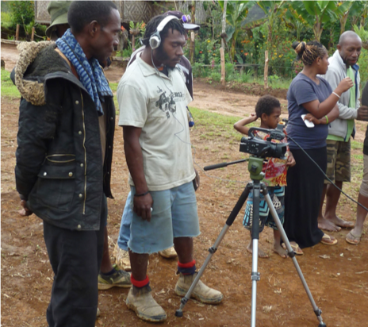

- Monitor recordings (as much as possible)
  - But *don't* continuously adjust sound levels
  - It's okay to peak when sound is loud

### Audio issues

- Keep sound levels from -20dB to -12dB
  - see Shut Up and Shoot, p. 196-197

No clipping

[interactive chart not shown]

Clipping

[interactive chart not shown]

### Signal to noise ratio

- Background noise is inevitable, but keep it at a minimum
- 10:1 = language is ten times as loud as background noise
- 1:1 = language is as lound as background noise

### Signal to noise ratio

A good signal to noise ratio can be acheived by considering…

- Microphone placement
- External noise (road noise, rain)
- Room acoustics

*Which recording has the better sound quality?*

[interactive chart not shown]

### Microphone placement

Maximize signal…

- Place microphone as close as possible
  - Microphone shouldn't be closer than 7-8 inches from speaker's mouth
  - Position headworn microphones to the side of the mouth
    - Read microphone instruction manual
  - In recording groups, consider the polar pattern
    - Move microphone closer to soft-spoken speakers

### Handling noise

**Avoid handling noise!**

[interactive chart not shown]

- Use cradles and mic stands
  - Not uncommon for people to touch microphone or play with table

### Room acoustics

- Sound waves bounce or rooms with lots of hard surfaces
- Dampen sound waves by using blankets, rugs, mattresses

[Bad room acoustics](https://youtu.be/cp56A6TcL1E?t=1s)

[Better room acoustics](https://youtu.be/cp56A6TcL1E?t=1m35s)

### Sources of noise

- Wind
  - Use a windsheild (e.g., deadcat)
- Traffic, rivers, generators
  - Record at a different time
  - Use polar patterns to your advantange
- Poor room acoustics
  - Use rugs, mattresses, blankets to dampen sound

### Sources of noise

- Fans, electronics, refrigerators
  - Turn off, Unplug (for a bit), move (if possible)
- Noise from participants or neighbors
  - Direct people elsewhere (if possible),
  - include them in on the recording

**It's important to work with trusted community members to help you ensure the best quality audio!**

### Audio problems

Can you spot the audio problems?

Turn sound low for this first example!

[interactive chart not shown]

### Recorders

Solid state recorders with XLR inputs:

- Good place to purchase: https://www.bhphotovideo.com
  - [Zoom H4n $299](https://www.bhphotovideo.com/c/product/1253811-REG/zoom_h4npro_4_channel_handy_recorder.html?sts=pi)
  - [Marantz PMD561 $299](https://www.bhphotovideo.com/c/product/1275332-REG/marantz_professional_pmd_561_professional_portable_audio_recorder.html)
  - [Tascam DR100MKIII $399](https://www.bhphotovideo.com/c/product/1263849-REG/tascam_dr_100mkiii_linear_pcm_recorder.html)
  - [Marantz PMD661 $499](https://www.bhphotovideo.com/c/product/1309681-REG/marantz_professional_pmd661mkiii_professional_portable_audio_recorder.html)
  - …

### Sampling rate

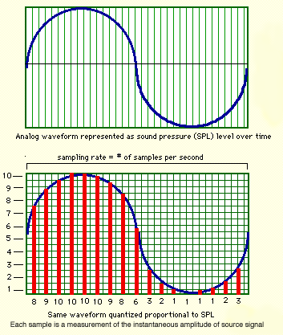

### Sampling rate

- 44.1 kHz or more
- Typically stereo
  - Maybe mono
- 16 bit or more

### Sampling rate differences

- Sampling rate 44.1kHz

[interactive chart not shown]

- Sampling rate 22.05kHz

[interactive chart not shown]

- Sampling rate 11.125kHz

[interactive chart not shown]

- Sampling rate 5.5125kHz

[interactive chart not shown]

- Sampling rate 4kHz

[interactive chart not shown]

### Basic audio setup

- [Zoom H4n $299](https://www.bhphotovideo.com/c/product/1253811-REG/zoom_h4npro_4_channel_handy_recorder.html?sts=pi)
- [Audio-Technica Stereo Microphone $249](https://www.bhphotovideo.com/c/product/761016-REG/Audio_Technica_AT2022_AT2022_X_Y_Stereo_Microphone.html)
- [Stereo XLR cable $24.95](https://www.bhphotovideo.com/c/product/994801-REG/rode_nt4_dxlr_cable_5_pin_stereo_xlr_cable.html)
- [Panasonic eneloop pro charger & batteries $52.99](https://www.bhphotovideo.com/c/product/1258154-REG/panasonic_k_kj17khc82a_eneloop_pro_high_capacity.html)
- [2 - SanDisk 16GB $21.94](https://www.bhphotovideo.com/c/product/1182600-REG/sandisk_sdsdxne_016g_gnci2_extreme_16gb_sdhc_u3.html)
- [Sony closed-back headphones $79.99](https://www.bhphotovideo.com/c/product/49510-REG/Sony_MDR_7506_MDR_7506_Headphone.html?sts=pi)

  **Total = 727.87**